# Personal_Loan_Campaign_Week2_Project

### Problem Statement

The majority of AllLife Bank's customers are deposit-only. Few of them, though, take out personal loans. The bank wants to convert more depositors into loan customers without losing them as depositors because loans generate more interest revenue.

The success percentage of a campaign last year was 9%, which was encouraging. To increase this success rate, the marketing team wants to use targeted campaigns to improve this success rate.

As a Data Scientist, your role is to build a model that predicts which customers are most likely to accept a personal loan, so that the marketing team can focus efforts on those high-potential customers.

### Objective

To predict whether a liability customer will buy personal loans, to understand which customer attributes are most significant in driving purchases, and to identify which segment of customers to target more.

### Data Dictionary

- ID: Customer ID
- Age: Age of customer
- Experience: Years of professional experience
- Income: Annual income of the customer (in thousand dollars)
- ZIP Code: Home Address ZIP code
- Family: Family size of the customer
- CCAvg: Average spending on credit cards per month (in thousand dollars)
- Education: Education Level - 1: Undergrad; 2: Graduate; 3: Advanced/Professional
- Mortgage: Value of house mortgage (if any) (in thousand dollars)
- Personal_Loan: Did this customer accept the personal loan offered in the last campaign?
- Securities_Account: Does the customer have a securities account with the bank?
- CD_Account: Does the customer have a certificate of deposit (CD) account with the bank? *nOnline: Do customers use Internet banking facilities?
- CreditCard: Does the customer use a credit card issued by any other Bank (excluding All Life Bank)?

### Importing necessary libraries

```python
# to load and manipulate data
import pandas as pd
import numpy as np

# to visualise data
import matplotlib.pyplot as plt
import seaborn as sns

# to split the data into train and test sets
from sklearn.model_selection import train_test_split

# to build a decision tree model
from sklearn.tree import DecisionTreeClassifier
from sklearn import tree

# to tune different models
from sklearn.model_selection import GridSearchCV

# to compute classification metrics
from sklearn.metrics import confusion_matrix, accuracy_score, precision_score, recall_score, f1_score, classification_report
```

### Loading the data

```python
from google.colab import drive
drive.mount('/content/drive')
```

```python
# loading data into a pandas dataframe
df = pd.read_csv("/content/drive/MyDrive/Personal Loan Campaign/Loan_Modelling.csv")
```

```python
# creating copy of the data
data = df.copy()
```

### Data background and contents

```python
data.head(5)    # checking the first 5 rows
```

|  | ID | Age | Experience | Income | ZIPCode | Family | CCAvg | Education | Mortgage | Personal_Loan | Securities_Account | CD_Account | Online | CreditCard |
| --- | --- | --- | --- | --- | --- | --- | --- | --- | --- | --- | --- | --- | --- | --- |
| 0 | 1 | 25 | 1 | 49 | 91107 | 4 | 1.6 | 1 | 0 | 0 | 1 | 0 | 0 | 0 |
| 1 | 2 | 45 | 19 | 34 | 90089 | 3 | 1.5 | 1 | 0 | 0 | 1 | 0 | 0 | 0 |
| 2 | 3 | 39 | 15 | 11 | 94720 | 1 | 1.0 | 1 | 0 | 0 | 0 | 0 | 0 | 0 |
| 3 | 4 | 35 | 9 | 100 | 94112 | 1 | 2.7 | 2 | 0 | 0 | 0 | 0 | 0 | 0 |
| 4 | 5 | 35 | 8 | 45 | 91330 | 4 | 1.0 | 2 | 0 | 0 | 0 | 0 | 0 | 1 |

Observation:

The first 5 rows of the data along with the title of the column has been displayed here.

```python
data.shape    # checking the shape of the data
```

```
(5000, 14)
```

Observation:

The data.shape is used to generate the number of rows and columns. Here the loan_modelling dataset has 5000 rows and 14 columns.

```python
data.info()   # checking the attribute types
```

```
<class 'pandas.core.frame.DataFrame'>
RangeIndex: 5000 entries, 0 to 4999
Data columns (total 14 columns):
 #   Column              Non-Null Count  Dtype
---  ------              --------------  -----
 0   ID                  5000 non-null   int64
 1   Age                 5000 non-null   int64
 2   Experience          5000 non-null   int64
 3   Income              5000 non-null   int64
 4   ZIPCode             5000 non-null   int64
 5   Family              5000 non-null   int64
 6   CCAvg               5000 non-null   float64
 7   Education           5000 non-null   int64
 8   Mortgage            5000 non-null   int64
 9   Personal_Loan       5000 non-null   int64
 10  Securities_Account  5000 non-null   int64
 11  CD_Account          5000 non-null   int64
 12  Online              5000 non-null   int64
 13  CreditCard          5000 non-null   int64
dtypes: float64(1), int64(13)
memory usage: 547.0 KB
```

Observation:

- There are 13 columns with integer (int64) values (ID, Age, Experience, Income, ZIPCode, Family, Education, Mortgage, Personal_Loan, Securities_Account, CD_Account, Online, CreditCard).
- There is 1 column with float (float64) value(CCAvg).

### Univariate Analysis

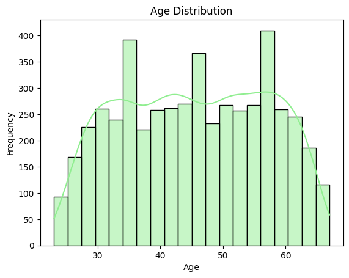

```python
# Distribution of Age

sns.histplot(df['Age'], bins=20, kde=True, color='lightgreen')
plt.title('Age Distribution')
plt.xlabel('Age')
plt.ylabel('Frequency')
plt.show()
```

Observation:

Most of the customers are between 30 years to 60 years.

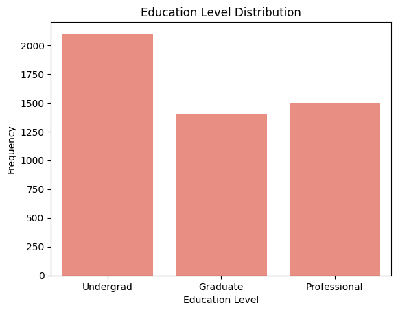

```python
# Education Level

sns.countplot(x='Education', data=df, color='salmon')
plt.title('Education Level Distribution')
plt.xlabel('Education Level')
plt.xticks([0,1,2], ['Undergrad', 'Graduate', 'Professional'])
plt.ylabel('Frequency')
plt.show()
```

Observation:

Higher number of customers are undergrads while the lower number of customers are graduates.

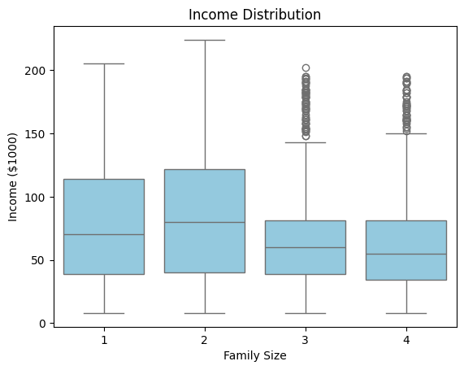

```python
# Family Size vs Income

sns.boxplot(x='Family', y='Income', data=df, color='skyblue')
plt.title('Income Distribution')
plt.xlabel('Family Size')
plt.ylabel('Income ($1000)')
plt.show()
```

Observation:

- The family of size 1 have a median around 70000 to 80000 dollars.
- The family size 2 has the highest income when compared to the other family sizes.
- The family of size 3 and 4 have lower income and more outliers.

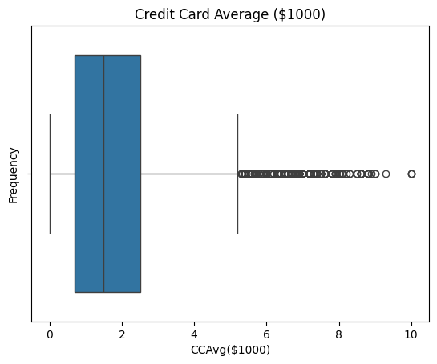

```python
# Credit Card Average

sns.boxplot(x='CCAvg', data=df)
plt.title('Credit Card Average ($1000)')
plt.xlabel('CCAvg($1000)')
plt.ylabel('Frequency')
plt.show()
```

Observation:

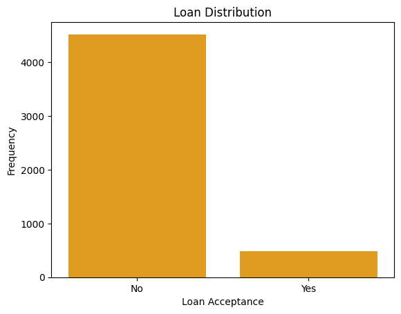

```python
# Personal Loan

sns.countplot(x='Personal_Loan', data=df, color='orange')
plt.title('Loan Distribution')
plt.xlabel('Loan Acceptance')
plt.xticks([0,1], ['No', 'Yes'])
plt.ylabel('Frequency')
plt.show()
```

Observation:

A higher number of customers did not accept the loan.

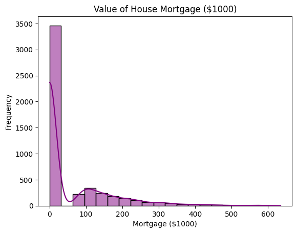

```python
# Value of House Mortgage

sns.histplot(df['Mortgage'], bins=20, kde=True, color='purple')
plt.title('Value of House Mortgage ($1000)')
plt.xlabel('Mortgage ($1000)')
plt.ylabel('Frequency')
plt.show()
```

Observation:

### Bivariate analysis

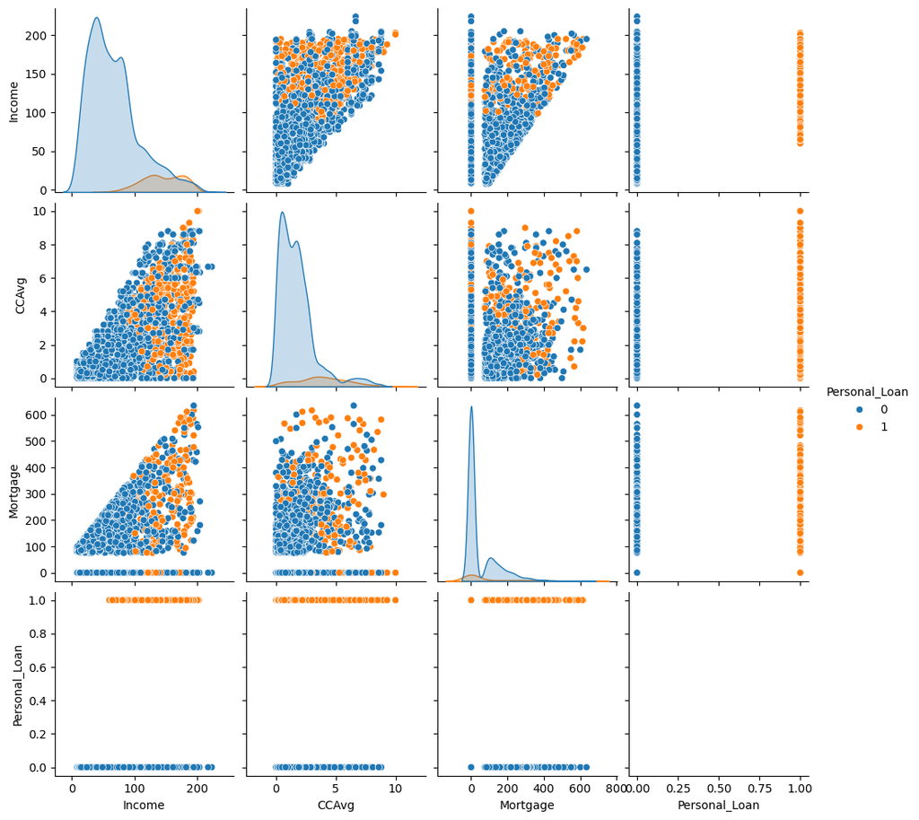

```python
# Pairplot to visualize Income, CCAvg, Mortgage, Personal_Loan

sns.pairplot(data=df, vars=['Income', 'CCAvg', 'Mortgage', 'Personal_Loan'], hue='Personal_Loan')
plt.show()
```

Observation:

- The pairplot shows that higher the income, higher is the credit card spending.
- The customers who accepted the personal loan have higher income when compared to the customers who didn't accept the personal loan.

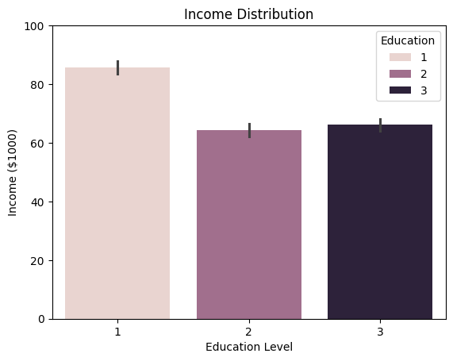

```python
# Education vs Income

sns.barplot(x='Education', y='Income', data=df, hue = 'Education')
plt.title('Income Distribution')
plt.xlabel("Education Level")
plt.ylim(0,100)
plt.ylabel("Income ($1000)")
plt.show()
```

Observation:

The bar plot depicts that the undergrads have higher income distribution when compared to the graduate and professional.

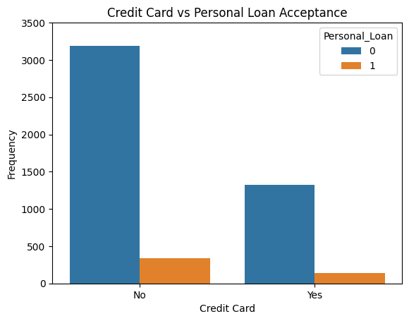

```python
# Credit Card vs Personal_Loan

sns.countplot(data=df, x='CreditCard', hue='Personal_Loan')
plt.title('Credit Card vs Personal Loan Acceptance')
plt.xlabel('Credit Card')
plt.xticks([0,1], ['No','Yes'])
plt.ylim(0,3500)
plt.ylabel('Frequency')
plt.show()
```

Observation:

- The customers who did not take loan are higher than the customers who took loan.
- Most of the customers do not use a credit card issued by any other Bank (excluding All Life Bank).

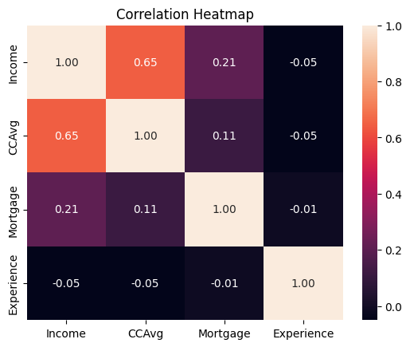

```python
# Heatmap to visualize Income, CCAvg, Mortgage, Experience

sns.heatmap(data=df[['Income', 'CCAvg', 'Mortgage', 'Experience']].corr(), annot=True, fmt=".2f")
plt.title('Correlation Heatmap')
plt.show()
```

Observation:

- The income and CCAvg have a strong positive correlation of 0.65.
- Experience has the lowest correlation with all the variables.
- Mortgage and experience have a negative correlation of -0.01.

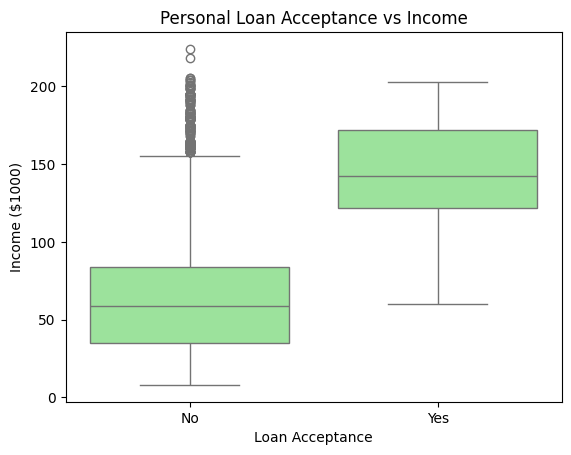

```python
# Income vs Loan Acceptance

sns.boxplot(x='Personal_Loan', y='Income', data=df, color='lightgreen')
plt.title('Personal Loan Acceptance vs Income')
plt.xlabel("Loan Acceptance")
plt.xticks([0,1], ['No','Yes'])
plt.ylabel('Income ($1000)')
plt.show()
```

Observation:

- Customers who accepted the loan have higher income when compared to customers who did not accept the loan.
- Outliers are present for the customers who did not accept the loan, but their overall income is less.

### Data pre-processing

```python
# checking the statistical summary

data.describe()
```

|  | ID | Age | Experience | Income | ZIPCode | Family | CCAvg | Education | Mortgage | Personal_Loan | Securities_Account | CD_Account | Online | CreditCard |
| --- | --- | --- | --- | --- | --- | --- | --- | --- | --- | --- | --- | --- | --- | --- |
| count | 5000.000000 | 5000.000000 | 5000.000000 | 5000.000000 | 5000.000000 | 5000.000000 | 5000.000000 | 5000.000000 | 5000.000000 | 5000.000000 | 5000.000000 | 5000.00000 | 5000.000000 | 5000.000000 |
| mean | 2500.500000 | 45.338400 | 20.104600 | 73.774200 | 93169.257000 | 2.396400 | 1.937938 | 1.881000 | 56.498800 | 0.096000 | 0.104400 | 0.06040 | 0.596800 | 0.294000 |
| std | 1443.520003 | 11.463166 | 11.467954 | 46.033729 | 1759.455086 | 1.147663 | 1.747659 | 0.839869 | 101.713802 | 0.294621 | 0.305809 | 0.23825 | 0.490589 | 0.455637 |
| min | 1.000000 | 23.000000 | -3.000000 | 8.000000 | 90005.000000 | 1.000000 | 0.000000 | 1.000000 | 0.000000 | 0.000000 | 0.000000 | 0.00000 | 0.000000 | 0.000000 |
| 25% | 1250.750000 | 35.000000 | 10.000000 | 39.000000 | 91911.000000 | 1.000000 | 0.700000 | 1.000000 | 0.000000 | 0.000000 | 0.000000 | 0.00000 | 0.000000 | 0.000000 |
| 50% | 2500.500000 | 45.000000 | 20.000000 | 64.000000 | 93437.000000 | 2.000000 | 1.500000 | 2.000000 | 0.000000 | 0.000000 | 0.000000 | 0.00000 | 1.000000 | 0.000000 |
| 75% | 3750.250000 | 55.000000 | 30.000000 | 98.000000 | 94608.000000 | 3.000000 | 2.500000 | 3.000000 | 101.000000 | 0.000000 | 0.000000 | 0.00000 | 1.000000 | 1.000000 |
| max | 5000.000000 | 67.000000 | 43.000000 | 224.000000 | 96651.000000 | 4.000000 | 10.000000 | 3.000000 | 635.000000 | 1.000000 | 1.000000 | 1.00000 | 1.000000 | 1.000000 |

Observation:

The statistical summary is found here. The minimum income is 8000 dollars while the maximum income is 224000 dollars.

```python
# checking for missing values

data.isnull().sum()
```

|  | 0 |
| --- | --- |
| ID | 0 |
| Age | 0 |
| Experience | 0 |
| Income | 0 |
| ZIPCode | 0 |
| Family | 0 |
| CCAvg | 0 |
| Education | 0 |
| Mortgage | 0 |
| Personal_Loan | 0 |
| Securities_Account | 0 |
| CD_Account | 0 |
| Online | 0 |
| CreditCard | 0 |

**dtype:** int64

Observation:

There are no missing values in the given dataset of loan_modelling.

```python
# checking for duplicate values

data.duplicated().sum()
```

```
np.int64(0)
```

Observation:

There are no duplicate values in the given dataset of loan_modelling.

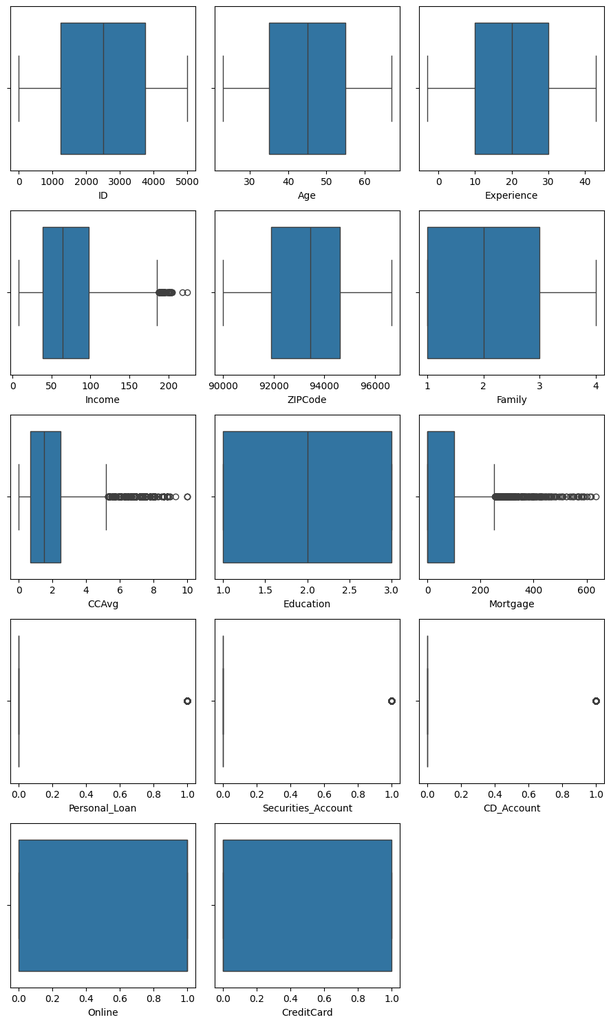

```python
# checking for outliers

import math

features = data.select_dtypes(include=['number']).columns.tolist()    # defining the numerical features to the plot

f = len(features)
cols = 3
rows = math.ceil(f/cols)

plt.figure(figsize=(3*cols, 3*rows))    # defining the figure size

for i, feature in enumerate(features):
  plt.subplot(rows, cols, i+1)
  sns.boxplot(data=df, x=feature)   # plotting box plot
plt.tight_layout()
plt.show()
```

Observation:

The income, CCAvg and mortgage have outliers present in the upper end.

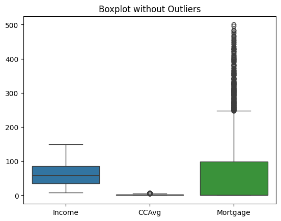

```python
# removal of outliers

def remove_outliers(df, column, threshold):
  outliers = df[df[column] <= threshold]

  sns.boxplot(outliers[column])
  plt.title("Boxplot without Outliers")
  plt.show()
  return outliers

columns = ['Income', 'CCAvg', 'Mortgage']
threshold = [150, 7, 500]
no_outliers = remove_outliers(df, columns, threshold)
```

Observation:

The income data does not have any outliers while the CCAvg have minor outliers and mortgage has outliers in its upper end.

```python
# Feature Engineering

dfe = df.copy()

dfe['Income_per_CCAvg'] = dfe['Income'] / (dfe['CCAvg'] + 1)    # Income per Credit Card Average Spend

dfe['Income_to_Mortgage'] = dfe['Income'] / (dfe['Mortgage'] + 1)   # Income to Mortgage Ratio

dfe['CCAvg_to_Mortgage'] = dfe['CCAvg'] / (dfe['Mortgage'] + 1)   # Credit Card Average to Mortgage Ratio

binary_columns = ['Personal_Loan', 'CreditCard', 'Online', 'Securities_Account']
for col in binary_columns:
    dfe[col] = dfe[col].map({0: 'No', 1: 'Yes'})

print("New features: ", dfe.columns.tolist())

dfe.head()
```

```
New features:  ['ID', 'Age', 'Experience', 'Income', 'ZIPCode', 'Family', 'CCAvg', 'Education', 'Mortgage', 'Personal_Loan', 'Securities_Account', 'CD_Account', 'Online', 'CreditCard', 'Income_per_CCAvg', 'Income_to_Mortgage', 'CCAvg_to_Mortgage']
```

|  | ID | Age | Experience | Income | ZIPCode | Family | CCAvg | Education | Mortgage | Personal_Loan | Securities_Account | CD_Account | Online | CreditCard | Income_per_CCAvg | Income_to_Mortgage | CCAvg_to_Mortgage |
| --- | --- | --- | --- | --- | --- | --- | --- | --- | --- | --- | --- | --- | --- | --- | --- | --- | --- |
| 0 | 1 | 25 | 1 | 49 | 91107 | 4 | 1.6 | 1 | 0 | NaN | NaN | 0 | NaN | NaN | 18.846154 | 49.0 | 1.6 |
| 1 | 2 | 45 | 19 | 34 | 90089 | 3 | 1.5 | 1 | 0 | NaN | NaN | 0 | NaN | NaN | 13.600000 | 34.0 | 1.5 |
| 2 | 3 | 39 | 15 | 11 | 94720 | 1 | 1.0 | 1 | 0 | NaN | NaN | 0 | NaN | NaN | 5.500000 | 11.0 | 1.0 |
| 3 | 4 | 35 | 9 | 100 | 94112 | 1 | 2.7 | 2 | 0 | NaN | NaN | 0 | NaN | NaN | 27.027027 | 100.0 | 2.7 |
| 4 | 5 | 35 | 8 | 45 | 91330 | 4 | 1.0 | 2 | 0 | NaN | NaN | 0 | NaN | NaN | 22.500000 | 45.0 | 1.0 |

Observation:

- The Income_per_CCAvg represents the income that is spent per unit of credit card. The higher values show high income with less credit usage and lower values show lower income or higher spending by the customer.
- The Income_to_Mortgage represents the rate of income per unit of mortgage.
- The CCAvg_to_Mortgage depicts the ratio of CCAvg to Mortgage.

```python
# Feature Engineering

dfb = dfe.copy()

dfb['Income_Value'] = pd.qcut(dfb['Income'], q=3, labels=['Low', 'Medium', 'High'])    # Income Values in terms of categorical values

binary_columns = ['Personal_Loan', 'CreditCard', 'Online', 'Securities_Account']

print("New features: ", dfb.columns.tolist())

dfb.head()
```

```
New features:  ['ID', 'Age', 'Experience', 'Income', 'ZIPCode', 'Family', 'CCAvg', 'Education', 'Mortgage', 'Personal_Loan', 'Securities_Account', 'CD_Account', 'Online', 'CreditCard', 'Income_per_CCAvg', 'Income_to_Mortgage', 'CCAvg_to_Mortgage', 'Income_Value']
```

|  | ID | Age | Experience | Income | ZIPCode | Family | CCAvg | Education | Mortgage | Personal_Loan | Securities_Account | CD_Account | Online | CreditCard | Income_per_CCAvg | Income_to_Mortgage | CCAvg_to_Mortgage | Income_Value |
| --- | --- | --- | --- | --- | --- | --- | --- | --- | --- | --- | --- | --- | --- | --- | --- | --- | --- | --- |
| 0 | 1 | 25 | 1 | 49 | 91107 | 4 | 1.6 | 1 | 0 | NaN | NaN | 0 | NaN | NaN | 18.846154 | 49.0 | 1.6 | Medium |
| 1 | 2 | 45 | 19 | 34 | 90089 | 3 | 1.5 | 1 | 0 | NaN | NaN | 0 | NaN | NaN | 13.600000 | 34.0 | 1.5 | Low |
| 2 | 3 | 39 | 15 | 11 | 94720 | 1 | 1.0 | 1 | 0 | NaN | NaN | 0 | NaN | NaN | 5.500000 | 11.0 | 1.0 | Low |
| 3 | 4 | 35 | 9 | 100 | 94112 | 1 | 2.7 | 2 | 0 | NaN | NaN | 0 | NaN | NaN | 27.027027 | 100.0 | 2.7 | High |
| 4 | 5 | 35 | 8 | 45 | 91330 | 4 | 1.0 | 2 | 0 | NaN | NaN | 0 | NaN | NaN | 22.500000 | 45.0 | 1.0 | Medium |

Observation:

The categorical feature of Income is created and it has 3 categories: Low, Medium, High.

### Data Preparation

```python
# defining features and targets
X = df.drop(columns=["Personal_Loan"])
y = df["Personal_Loan"]

X = pd.get_dummies(X, drop_first=True)    # creating dummy variables

X = X.astype(int)

# splitting the dataset into train and test
X_train, X_test, y_train, y_test = train_test_split(
    X,    # specifying independent variables
    y,    # specifying dependent variables
    test_size=0.2,    # specifying the size of the test set
    stratify = y,   # ensures that training and test set have similar distribution of response variable
    random_state=42)    # specifying the seed value to enable reproducible results
```

Observation:

- The target variable is the Personal_Loan and other columns are the features.
- The dataset is split into traning anf test set with a ratio of 80:20 and it ensures reproductibility of results at a random_state of 42.

```python
print("Shape of training set: ", X_train.shape)
print("Shape of test set: ", X_test.shape)
```

```
Shape of training set:  (4000, 13)
Shape of test set:  (1000, 13)
```

Observation:

The shape of training set has 4000 rows and 13 columns while test set has 1000 rows and 13 columns.

### Model Building

```python
# creating an instance of decision tree
dtree1 = DecisionTreeClassifier(random_state=42)

# fitting the model to training set
dtree1.fit(X_train, y_train)
```

```
DecisionTreeClassifier(random_state=42)
```

### Model Evaluation

```python
y_pred = dtree1.predict(X_test)
print("\t\t\tModel Evaluation")
print("Accuracy:", accuracy_score(y_test, y_pred))    # to compute accuracy
print("Precision:", precision_score(y_test, y_pred))    # to compute precision
print("Recall:", recall_score(y_test, y_pred))    # to compute recall
print("F1 Score:", f1_score(y_test, y_pred))    # to compute f1-score
print("Classification Report:\n", classification_report(y_test, y_pred))
```

```
			Model Evaluation
Accuracy: 0.983
Precision: 0.8691588785046729
Recall: 0.96875
F1 Score: 0.916256157635468
Classification Report:
               precision    recall  f1-score   support

           0       1.00      0.98      0.99       904
           1       0.87      0.97      0.92        96

    accuracy                           0.98      1000
   macro avg       0.93      0.98      0.95      1000
weighted avg       0.98      0.98      0.98      1000
```

Observation:

- The model gives an excellent accuracy of 98.3% indicating that that 983 instances have been classified correctly out of 1000 instances.
- For class 0, the model is accurate in identifying the customers who did not take loan and hence the precisin, recall and f1-score are 100%, 98% and 99% respectively.
- For class 1, the precision is 87%. This means that when the model predicts a loan, it is correct 87% of the time.
- For class 1, the recall and f1-score are 97% and 92% respectively which makes the model suitable for finding the loan acceptance among the customers.

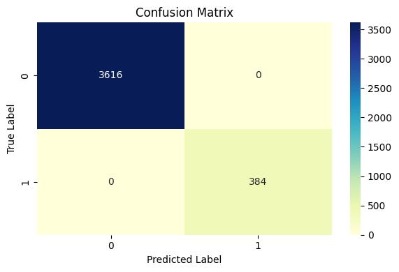

```python
# Confusion matrix for training set

model = DecisionTreeClassifier()
model.fit(X_train, y_train)

y_pred_train = model.predict(X_train)

con_mat_train = confusion_matrix(y_train, y_pred_train)

plt.figure(figsize=(6,4))
sns.heatmap(con_mat_train, annot=True, fmt='d', cmap='YlGnBu')
plt.title('Confusion Matrix')
plt.xlabel('Predicted Label')
plt.ylabel('True Label')
plt.tight_layout()
plt.show()
```

Observation:

The value of True Positive (TP) is 384 and that of True Negative (TN) is 3616.

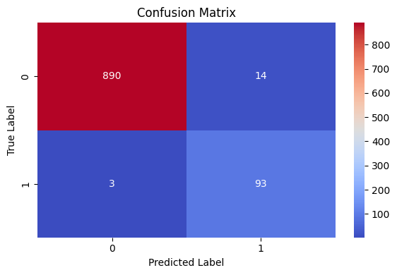

```python
# Confusion matrix for test set

con_mat = confusion_matrix(y_test, y_pred)

plt.figure(figsize=(6,4))
sns.heatmap(con_mat, annot=True, fmt='d', cmap='coolwarm')
plt.title('Confusion Matrix')
plt.xlabel('Predicted Label')
plt.ylabel('True Label')
plt.tight_layout()
plt.show()
```

Observation:

- The overall accuracy and recall is high which makes the model a strong classification model.
- The model performs well in class 1.

### Visualizing the Decision Tree

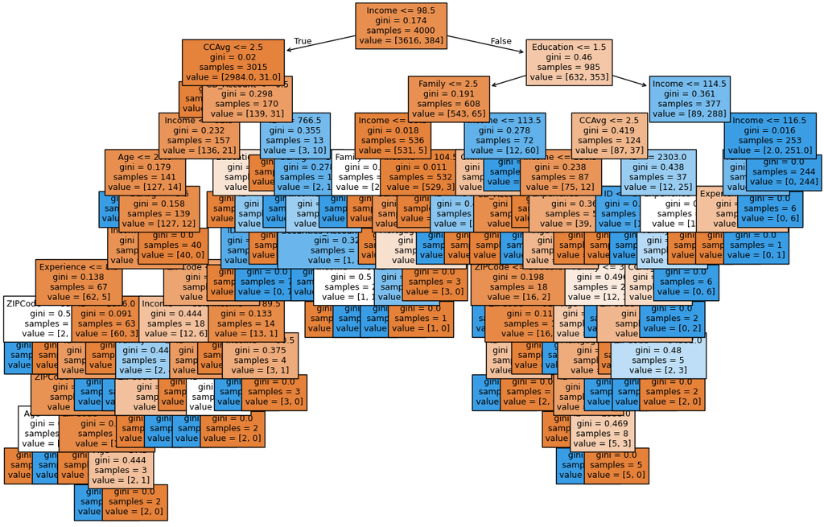

```python
# list of feature names in X_train
feature_name = list(X_train.columns)

# figure size for plot
plt.figure(figsize=(15,10))

# plotting decision tree
out = tree.plot_tree(
    dtree1,                         # decision tree classifier model
    feature_names=feature_name,     # list of feature names in dataset
    filled=True,                    # fill the nodes with colors based on class
    fontsize=9,                     # font size for node text
    node_ids=False,                 # ID of each node
    class_names=None,)              # class names to be displayed or not

# adding arrows for decision tree splits
for o in out:
  arrow = o.arrow_patch
  if arrow is not None:
    arrow.set_edgecolor('black')
    arrow.set_linewidth(1)

plt.show()
```

Observation:

The resultant decision tree seems to be complex tree.

```python
# printing the text report of the decision tree
print(
    tree.export_text(
        dtree1,       # defining the model
        feature_names=feature_name,       # defining the feature name
        show_weights=True
    )
)
```

```
|--- Income <= 98.50
|   |--- CCAvg <= 2.50
|   |   |--- weights: [2845.00, 0.00] class: 0
|   |--- CCAvg >  2.50
|   |   |--- CD_Account <= 0.50
|   |   |   |--- Income <= 92.50
|   |   |   |   |--- Age <= 27.00
|   |   |   |   |   |--- weights: [0.00, 2.00] class: 1
|   |   |   |   |--- Age >  27.00
|   |   |   |   |   |--- CCAvg <= 3.50
|   |   |   |   |   |   |--- Income <= 82.50
|   |   |   |   |   |   |   |--- Experience <= 8.50
|   |   |   |   |   |   |   |   |--- ZIPCode <= 93199.00
|   |   |   |   |   |   |   |   |   |--- weights: [0.00, 2.00] class: 1
|   |   |   |   |   |   |   |   |--- ZIPCode >  93199.00
|   |   |   |   |   |   |   |   |   |--- weights: [2.00, 0.00] class: 0
|   |   |   |   |   |   |   |--- Experience >  8.50
|   |   |   |   |   |   |   |   |--- ID <= 1676.00
|   |   |   |   |   |   |   |   |   |--- ID <= 1497.50
|   |   |   |   |   |   |   |   |   |   |--- ZIPCode <= 91257.00
|   |   |   |   |   |   |   |   |   |   |   |--- truncated branch of depth 2
|   |   |   |   |   |   |   |   |   |   |--- ZIPCode >  91257.00
|   |   |   |   |   |   |   |   |   |   |   |--- truncated branch of depth 3
|   |   |   |   |   |   |   |   |   |--- ID >  1497.50
|   |   |   |   |   |   |   |   |   |   |--- weights: [0.00, 1.00] class: 1
|   |   |   |   |   |   |   |   |--- ID >  1676.00
|   |   |   |   |   |   |   |   |   |--- weights: [45.00, 0.00] class: 0
|   |   |   |   |   |   |--- Income >  82.50
|   |   |   |   |   |   |   |--- ZIPCode <= 94413.00
|   |   |   |   |   |   |   |   |--- Income <= 83.50
|   |   |   |   |   |   |   |   |   |--- Family <= 2.50
|   |   |   |   |   |   |   |   |   |   |--- weights: [0.00, 3.00] class: 1
|   |   |   |   |   |   |   |   |   |--- Family >  2.50
|   |   |   |   |   |   |   |   |   |   |--- ZIPCode <= 93703.00
|   |   |   |   |   |   |   |   |   |   |   |--- weights: [2.00, 0.00] class: 0
|   |   |   |   |   |   |   |   |   |   |--- ZIPCode >  93703.00
|   |   |   |   |   |   |   |   |   |   |   |--- weights: [0.00, 1.00] class: 1
|   |   |   |   |   |   |   |   |--- Income >  83.50
|   |   |   |   |   |   |   |   |   |--- ID <= 3722.00
|   |   |   |   |   |   |   |   |   |   |--- weights: [8.00, 0.00] class: 0
```

[output cut: 132 more lines]

```
|   |   |   |   |   |   |--- Family >  2.50
|   |   |   |   |   |   |   |--- weights: [0.00, 6.00] class: 1
|   |   |   |   |   |--- Experience >  35.50
|   |   |   |   |   |   |--- weights: [4.00, 0.00] class: 0
|   |   |--- Income >  114.50
|   |   |   |--- Income <= 116.50
|   |   |   |   |--- Family <= 1.50
|   |   |   |   |   |--- Experience <= 20.00
|   |   |   |   |   |   |--- weights: [2.00, 0.00] class: 0
|   |   |   |   |   |--- Experience >  20.00
|   |   |   |   |   |   |--- weights: [0.00, 1.00] class: 1
|   |   |   |   |--- Family >  1.50
|   |   |   |   |   |--- weights: [0.00, 6.00] class: 1
|   |   |   |--- Income >  116.50
|   |   |   |   |--- weights: [0.00, 244.00] class: 1
```

Observation:

The decision tree of dtree1 is depicted in format of text report.

### Decision Tree - Before Pruning

```
Decision tree before pruning:
              precision    recall  f1-score   support

           0       1.00      0.98      0.99       904
           1       0.87      0.97      0.92        96

    accuracy                           0.98      1000
   macro avg       0.93      0.98      0.95      1000
weighted avg       0.98      0.98      0.98      1000
```

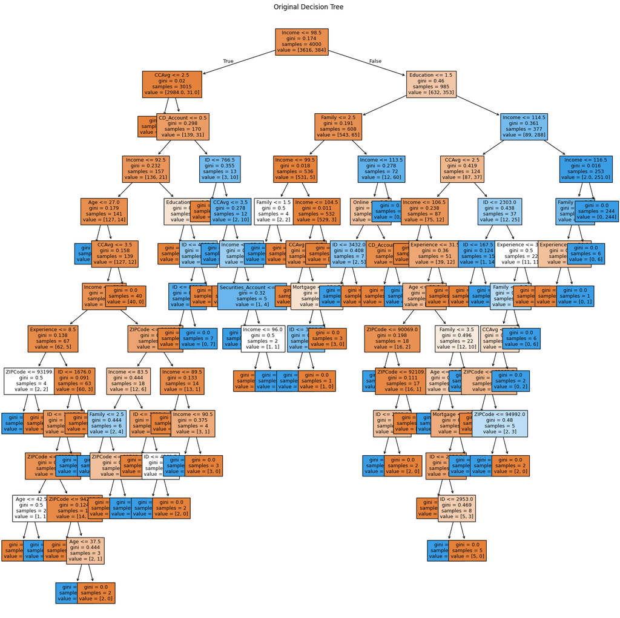

```python
y_pred_before = dtree1.predict(X_test)

print("Decision tree before pruning: ")
print(classification_report(y_test, y_pred_before))

# plotting decision tree
plt.figure(figsize=(20,20))

out = tree.plot_tree(
    dtree1,                         # decision tree classifier model
    feature_names=feature_name,     # list of feature names in dataset
    filled=True,                    # fill the nodes with colors based on class
    fontsize=9,                     # font size for node text
    node_ids=False,                 # ID of each node
    class_names=None,)

plt.title("Original Decision Tree\n")
plt.show()
```

Observation:

A very complex decision tree is created with high number of levels and nodes.

```python
# creating another instance for decision tree
dtree2 = DecisionTreeClassifier(
    max_depth = 6,
    max_leaf_nodes = 20,
    min_samples_split = 50,
    random_state=42
)

# fitting the model to training set
dtree2.fit(X_train, y_train)
```

```
DecisionTreeClassifier(max_depth=6, max_leaf_nodes=20, min_samples_split=50,
                       random_state=42)
```

Observation:

The DecisionTreeClassifier of dtree2 is created for pre-pruning of the decision tree.

### Pre-Pruning of Decision Tree

```
Decision tree - pre pruning:
              precision    recall  f1-score   support

           0       1.00      0.99      0.99       904
           1       0.94      0.96      0.95        96

    accuracy                           0.99      1000
   macro avg       0.97      0.98      0.97      1000
weighted avg       0.99      0.99      0.99      1000
```

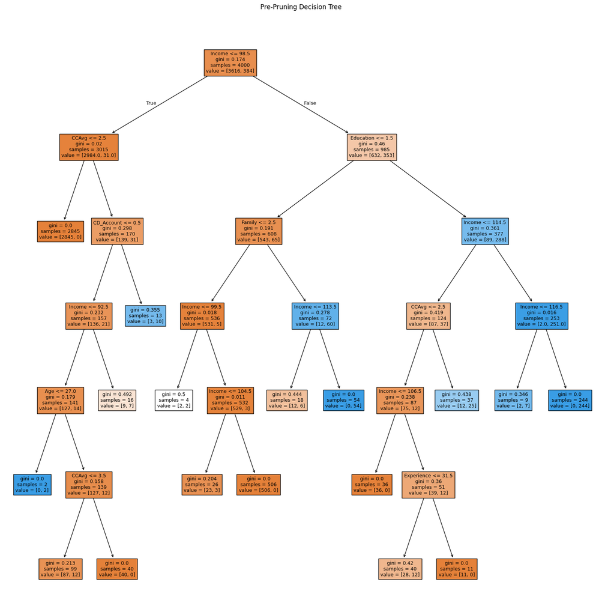

```python
dtree2.fit(X_train, y_train)
y_pred_pre = dtree2.predict(X_test)

print("Decision tree - pre pruning: ")
print(classification_report(y_test, y_pred_pre))

# list of feature names in X_train
feature_name = list(X_train.columns)

# figure size for plot
plt.figure(figsize=(20,20))

# plotting decision tree
out = tree.plot_tree(
    dtree2,                         # decision tree classifier model
    feature_names=feature_name,     # list of feature names in dataset
    filled=True,                    # fill the nodes with colors based on class
    fontsize=9,                     # font size for node text
    node_ids=False,                 # ID of each node
    class_names=None,)              # class names to be displayed or not

# adding arrows for decision tree splits
for o in out:
  arrow = o.arrow_patch
  if arrow is not None:
    arrow.set_edgecolor('black')
    arrow.set_linewidth(1)

plt.title("Pre-Pruning Decision Tree\n")
plt.show()
```

Observation:

This tree provides a simplified version of the original tree and has less number of levels and nodes when compared to the original tree.

```python
# printing the text report of the decision tree
print(
    tree.export_text(
        dtree2,       # defining the model
        feature_names=feature_name,       # defining the feature name
        show_weights=True
    )
)
```

```
|--- Income <= 98.50
|   |--- CCAvg <= 2.50
|   |   |--- weights: [2845.00, 0.00] class: 0
|   |--- CCAvg >  2.50
|   |   |--- CD_Account <= 0.50
|   |   |   |--- Income <= 92.50
|   |   |   |   |--- Age <= 27.00
|   |   |   |   |   |--- weights: [0.00, 2.00] class: 1
|   |   |   |   |--- Age >  27.00
|   |   |   |   |   |--- CCAvg <= 3.50
|   |   |   |   |   |   |--- weights: [87.00, 12.00] class: 0
|   |   |   |   |   |--- CCAvg >  3.50
|   |   |   |   |   |   |--- weights: [40.00, 0.00] class: 0
|   |   |   |--- Income >  92.50
|   |   |   |   |--- weights: [9.00, 7.00] class: 0
|   |   |--- CD_Account >  0.50
|   |   |   |--- weights: [3.00, 10.00] class: 1
|--- Income >  98.50
|   |--- Education <= 1.50
|   |   |--- Family <= 2.50
|   |   |   |--- Income <= 99.50
|   |   |   |   |--- weights: [2.00, 2.00] class: 0
|   |   |   |--- Income >  99.50
|   |   |   |   |--- Income <= 104.50
|   |   |   |   |   |--- weights: [23.00, 3.00] class: 0
|   |   |   |   |--- Income >  104.50
|   |   |   |   |   |--- weights: [506.00, 0.00] class: 0
|   |   |--- Family >  2.50
|   |   |   |--- Income <= 113.50
|   |   |   |   |--- weights: [12.00, 6.00] class: 0
|   |   |   |--- Income >  113.50
|   |   |   |   |--- weights: [0.00, 54.00] class: 1
|   |--- Education >  1.50
|   |   |--- Income <= 114.50
|   |   |   |--- CCAvg <= 2.50
|   |   |   |   |--- Income <= 106.50
|   |   |   |   |   |--- weights: [36.00, 0.00] class: 0
|   |   |   |   |--- Income >  106.50
|   |   |   |   |   |--- Experience <= 31.50
|   |   |   |   |   |   |--- weights: [28.00, 12.00] class: 0
|   |   |   |   |   |--- Experience >  31.50
|   |   |   |   |   |   |--- weights: [11.00, 0.00] class: 0
|   |   |   |--- CCAvg >  2.50
|   |   |   |   |--- weights: [12.00, 25.00] class: 1
|   |   |--- Income >  114.50
|   |   |   |--- Income <= 116.50
|   |   |   |   |--- weights: [2.00, 7.00] class: 1
|   |   |   |--- Income >  116.50
|   |   |   |   |--- weights: [0.00, 244.00] class: 1
```

Observation:

The decision tree of dtree2 is depicted in format of text report.

### Post Pruning of Decision Tree

```python
# creating an instance for decision tree
dtree3 = DecisionTreeClassifier(random_state=42)

path=dtree3.cost_complexity_pruning_path(X_train, y_train)    # cost complexity for pruning the path
ccp_alphas, impurities = path.ccp_alphas, path.impurities     # extracting alphas and impurities

pd.DataFrame(path)
```

|  | ccp_alphas | impurities |
| --- | --- | --- |
| 0 | 0.000000 | 0.000000 |
| 1 | 0.000200 | 0.000400 |
| 2 | 0.000217 | 0.000833 |
| 3 | 0.000221 | 0.001716 |
| 4 | 0.000232 | 0.002180 |
| 5 | 0.000235 | 0.002651 |
| 6 | 0.000273 | 0.003197 |
| 7 | 0.000321 | 0.003517 |
| 8 | 0.000331 | 0.004509 |
| 9 | 0.000333 | 0.005176 |
| 10 | 0.000365 | 0.008099 |
| 11 | 0.000373 | 0.009590 |
| 12 | 0.000418 | 0.010008 |
| 13 | 0.000438 | 0.010446 |
| 14 | 0.000455 | 0.010900 |
| 15 | 0.000467 | 0.011367 |
| 16 | 0.000486 | 0.012825 |
| 17 | 0.000493 | 0.013811 |
| 18 | 0.000500 | 0.015311 |
| 19 | 0.000550 | 0.017510 |
| 20 | 0.000584 | 0.018094 |
| 21 | 0.000613 | 0.018707 |
| 22 | 0.000646 | 0.019998 |
| 23 | 0.000714 | 0.020713 |
| 24 | 0.000823 | 0.021535 |
| 25 | 0.000831 | 0.022367 |
| 26 | 0.000837 | 0.023204 |
| 27 | 0.000870 | 0.024945 |
| 28 | 0.002424 | 0.027369 |
| 29 | 0.002667 | 0.030036 |
| 30 | 0.003000 | 0.033036 |
| 31 | 0.003753 | 0.036789 |
| 32 | 0.020023 | 0.056812 |
| 33 | 0.021549 | 0.078361 |
| 34 | 0.047604 | 0.173568 |

Observation:

```
Decision tree - post pruning:
              precision    recall  f1-score   support

           0       1.00      0.98      0.99       904
           1       0.87      0.97      0.92        96

    accuracy                           0.98      1000
   macro avg       0.93      0.98      0.95      1000
weighted avg       0.98      0.98      0.98      1000
```

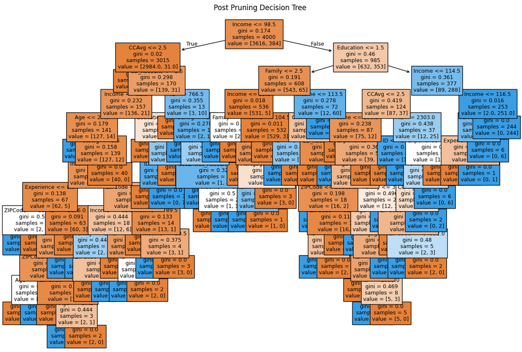

```python
dtree3.fit(X_train, y_train)
y_pred_post = dtree3.predict(X_test)

print("Decision tree - post pruning: ")
print(classification_report(y_test, y_pred_post))

# list of feature names in X_train
feature_name = list(X_train.columns)

# setting the figure size
plt.figure(figsize=(15, 10))

# plotting decision tree
out = tree.plot_tree(
    dtree3,                         # decision tree classifier model
    feature_names=feature_name,     # list of feature names in dataset
    filled=True,                    # fill the nodes with colors based on class
    fontsize=9,                     # font size for node text
    node_ids=False,                 # ID of each node
    class_names=None,)              # class names to be displayed or not

# adding arrows for decision tree splits
for o in out:
  arrow = o.arrow_patch
  if arrow is not None:
    arrow.set_edgecolor('black')
    arrow.set_linewidth(1)
plt.title("Post Pruning Decision Tree\n")
plt.show()
```

Observation:

```python
models_info = {
    "Base": dtree1,
    "Pre-Pruned": dtree2,
    "Post-Pruned": dtree3
}

for name, i in models_info.items():
    y_pred_compare = i.predict(X_test)
    print(f"\n{name} Model Accuracy: {accuracy_score(y_test, y_pred):.4f}")
```

[output not shown]

### Model Performance Comparison and Final Model Selection

```python
# defining function to check the performance of the model
def model_performance_classification(model, predictors, target):
  pred = model.predict(predictors)

  acc = accuracy_score(target, pred)      # compting accuracy
  prec = precision_score(target, pred)    # compting precision
  rec = recall_score(target, pred)        # compting recall
  f1 = f1_score(target, pred)             # compting f1-score

  # creating dataframe of metrics
  df_perf = pd.DataFrame(
      {'Accuracy':acc, 'Precision':prec, 'Recall':rec, 'F1-Score':f1,},index=[0],)

  return df_perf
```

```python
dtree1_train_perf = model_performance_classification(dtree1, X_train, y_train)
dtree1_test_perf = model_performance_classification(dtree1, X_test, y_test)
print("Decision Tree Classifier1 - Training Set\n",dtree1_train_perf)
print("\n")
print("Decision Tree Classifier1 - Test Set\n",dtree1_test_perf)
```

```
Decision Tree Classifier1 - Training Set
       Metric  Value
0   Accuracy    1.0
1  Precision    1.0
2     Recall    1.0
3   F1-Score    1.0


Decision Tree Classifier1 - Test Set
       Metric     Value
0   Accuracy  0.983000
1  Precision  0.869159
2     Recall  0.968750
3   F1-Score  0.916256
```

```python
dtree2_train_perf = model_performance_classification(dtree2, X_train, y_train)
dtree2_test_perf = model_performance_classification(dtree2, X_test, y_test)
print("Decision Tree Classifier2 - Training Set\n",dtree2_train_perf)
print("\n")
print("Decision Tree Classifier2 - Test Set\n",dtree2_test_perf)
```

```
Decision Tree Classifier2 - Training Set
       Metric     Value
0   Accuracy  0.985250
1  Precision  0.952646
2     Recall  0.890625
3   F1-Score  0.920592


Decision Tree Classifier2 - Test Set
       Metric     Value
0   Accuracy  0.990000
1  Precision  0.938776
2     Recall  0.958333
3   F1-Score  0.948454
```

```python
dtree3_train_perf = model_performance_classification(dtree3, X_train, y_train)
dtree3_test_perf = model_performance_classification(dtree3, X_test, y_test)
print("Decision Tree Classifier3 - Training Set\n",dtree3_train_perf)
print("\n")
print("Decision Tree Classifier3 - Test Set\n",dtree3_test_perf)
```

```
Decision Tree Classifier3 - Training Set
       Metric  Value
0   Accuracy    1.0
1  Precision    1.0
2     Recall    1.0
3   F1-Score    1.0


Decision Tree Classifier3 - Test Set
       Metric     Value
0   Accuracy  0.983000
1  Precision  0.869159
2     Recall  0.968750
3   F1-Score  0.916256
```

```python
# performance comparison - training data

models_train_comp = pd.concat([dtree1_train_perf, dtree2_train_perf, dtree3_train_perf],
                              axis=1,
                              keys = ['Before Pruning', 'Pre-Pruning', 'Post-Pruning'])
print("Training data performance comparison:\n\n", models_train_comp)
```

```
Training data performance comparison:

           Before Pruning Pre-Pruning Post-Pruning
                   Value       Value        Value
Metric
Accuracy             1.0    0.985250          1.0
Precision            1.0    0.952646          1.0
Recall               1.0    0.890625          1.0
F1-Score             1.0    0.920592          1.0
```

Observation:

```python
# performance comparison - test data

models_test_comp = pd.concat([dtree1_test_perf, dtree2_test_perf, dtree3_test_perf],
                              axis=1,
                              keys = ['Before Pruning', 'Pre-Pruning', 'Post-Pruning'])
print("Test data performance comparison:\n\n", models_test_comp)
```

```
Test data performance comparison:

   Before Pruning           Pre-Pruning           Post-Pruning
          Metric     Value      Metric     Value       Metric     Value
0       Accuracy  0.983000    Accuracy  0.990000     Accuracy  0.983000
1      Precision  0.869159   Precision  0.938776    Precision  0.869159
2         Recall  0.968750      Recall  0.958333       Recall  0.968750
3       F1-Score  0.916256    F1-Score  0.948454     F1-Score  0.916256
```

Observation:

Observation on Final Model Selection:

- The pre-pruning decision model (dtree2) has better performance and is more reliable model when compared to the dtree1 and dtree3 model which is the before pruning decision tree and post pruning decision tree.

### Feature Importance

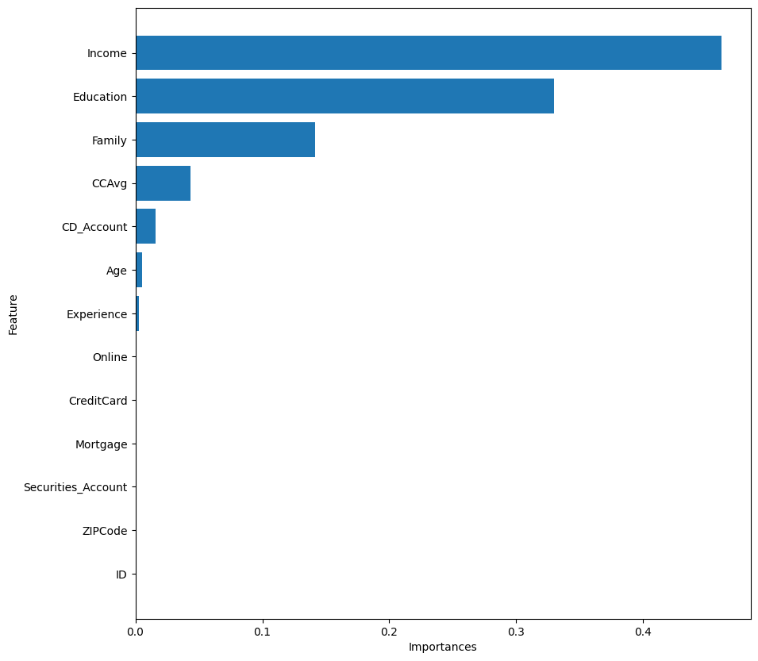

```python
# feature importance in decision tree building
imp = dtree2.feature_importances_
ind = np.argsort(imp)
plt.figure(figsize=(10,10))
plt.barh(range(len(indices)), imp[ind], align='center')
plt.xlabel('Importances')
plt.ylabel('Feature')
plt.yticks(range(len(ind)), np.array(X_train.columns)[ind])
plt.show()
```

Observation:

- The Income and Education are highly influential attributes in determining the Loan purchasing by the customer.

### Key takeaways for the marketing team

- Among the three decision tree classifier models, the model of the pre-pruning tree (dtree2) gives the best accuracy of 0.990, precision of 0.938, recall of 0.958 and f1-score of 0.948.
- The unpruned decision tree of before pruning has 100% accuracy on the training data but it indicates the overfitting.
- The correlation between the income and credit card average spending is strong positive correlation (0.65).
- From the pairplot, we can confirm that the customers with higher income levels are likely to accept the personal loans when compared to those with lower income.
- The undergrads have higher income distribution when compared to the graduate and professional.
- An average portion of loan acceptors use online banking and credit card features and this depicts that these customers would be comfortable in using the digital communication.

### Conclusion

- The customers with the higher income are more likely to accept the personal loan.
- Undergrads have higher income than graduates and professionals.
- There are no missing values or duplicate values in the dataset which significantly makes the model efficient and reliable.
- Outliers are present in mortgage and CCAvg but they do not affect the model's performance.
- Families of size 2 have higher income when compared to the other families.
- The pre-pruned decision tree model is best in performance and it has high accuracy, precision, recall and f1-score.